# NKI Demographics

Below follows the preprocessing of the NKI demographics data. We ultimately want:

- Age
- Sex
- Race
- Education
- Handedness
- Parent’s education
- BMI

```r
library(tidyverse)
library(naniar)
library(ggsankey)
library(forcats)
library(here)

data_path <- here("data")
```

# Read in

```r
nki_raw1 <- read_csv(here(data_path, "RocklandSample_04JAN2021.csv")) %>%
  rename("participant_id" = Identifiers) %>%
  separate(participant_id, c("participant_id", "wave"))
nki_raw2 <- read_csv(here(data_path, "RocklandSample_01SET2021_cog.csv")) %>%
  rename("participant_id" = Identifiers) %>%
  separate(participant_id, c("participant_id", "wave"))
```

```
One or more parsing issues, see `problems()` for detailsRows: 2442 Columns: 268── Column specification ─────────────────────────────────────────────────────
```

```r
nki_ehq <- read_csv(here(data_path, "NKI_EHQ_data-2022-03-17T18_27_10.630Z.csv")) %>%
  rename("participant_id" = Identifiers) %>%
  separate(participant_id, c("participant_id", "wave"))
nki_ses <- read_csv(here(data_path, "NKI_SES_data-2022-03-18T03_07_58.757Z.csv")) %>%
  rename("participant_id" = Identifiers) %>%
  separate(participant_id, c("participant_id", "wave"))
```

**NOTE**

The NKI team mentioned to us that BAS1 BAS2 BAS3 are inconsequential differentiators. Instead, everyone with a BAS is considered a BASELINE visit. Individuals who return then get a FLU1 (follow up) visit. Those who return multiple times then get a TRT (treatment) visit, but we do not need to differentiate these – they are just called FLU 1 and 2.

```r
nki_wave_levels <- c(1, 1, 1, 2, 3, 3)
nki_wave_labels <- c('BAS1', 'BAS2', 'BAS3', 'FLU1', 'FLU2', 'FLU3')

nki_raw <- nki_raw1 %>%
  left_join(nki_raw2, by=c("participant_id", "wave")) %>%
  left_join(nki_ehq, by=c("participant_id", "wave")) %>%
  left_join(nki_ses, by=c("participant_id", "wave")) %>%
  mutate(participant_id = str_c("sub-", participant_id))
nki_ <- nki_raw %>%
  mutate(
    wave = case_when(
      wave == "BAS1"    ~ 1,
      wave == "BAS2"    ~ 1,
      wave == "BAS3"    ~ 1,
      wave == "FLU1"    ~ 2,
      wave == "FLU2"    ~ 3,
      wave == "FLU3"    ~ 3
      ) %>% factor(levels = nki_wave_levels, labels =nki_wave_labels)
    )
```

```r
nki_ %>%
  sample_n(30) %>%
  select(-participant_id)
```

| wave | age_04 | nkicbcl_001 | nkicbcl_002a | nkicbcl_003 | nkicbcl_004 | nkicbcl_005 | nkicbcl_006 | nkicbcl_007 | nkicbcl_008 | nkicbcl_009a | nkicbcl_010 | nkicbcl_011 | nkicbcl_012 | nkicbcl_013 | nkicbcl_014 | nkicbcl_015 | nkicbcl_016 | nkicbcl_017 | nkicbcl_018 | nkicbcl_019 | nkicbcl_020 | nkicbcl_021 | nkicbcl_022 | nkicbcl_023 | nkicbcl_024 | nkicbcl_025 | nkicbcl_026 | nkicbcl_027 | nkicbcl_028 | … |
| --- | --- | --- | --- | --- | --- | --- | --- | --- | --- | --- | --- | --- | --- | --- | --- | --- | --- | --- | --- | --- | --- | --- | --- | --- | --- | --- | --- | --- | --- | --- |
| FLU1 | 8.328767123287701 | 0 | 0 | 1 | 0 | 0 | 0 | 1 | 1 | 0 | 0 | 0 | 0 | 0 | 0 | 0 | 0 | 0 | 0 | 0 | 0 | 0 | 0 | 0 | 0 | 0 | 0 | 0 | 1 | … |
| BAS1 | 66.613698630137 | . | . | . | . | . | . | . | . | . | . | . | . | . | . | . | . | . | . | . | . | . | . | . | . | . | . | . | . | … |
| FLU1 | 51.484931506849 | . | . | . | . | . | . | . | . | . | . | . | . | . | . | . | . | . | . | . | . | . | . | . | . | . | . | . | . | … |
| FLU1 | 18.583561643836 | NA | NA | NA | NA | NA | NA | NA | NA | NA | NA | NA | NA | NA | NA | NA | NA | NA | NA | NA | NA | NA | NA | NA | NA | NA | NA | NA | NA | … |
| BAS1 | 54.386301369863006 | . | . | . | . | . | . | . | . | . | . | . | . | . | . | . | . | . | . | . | . | . | . | . | . | . | . | . | . | … |
| BAS1 | 33.38904109589 | . | . | . | . | . | . | . | . | . | . | . | . | . | . | . | . | . | . | . | . | . | . | . | . | . | . | . | . | … |
| FLU2 | 14.638356164384 | 0 | 0 | 0 | 0 | 0 | 0 | 1 | 0 | 1 | 0 | 0 | 0 | 0 | 0 | 0 | 0 | 0 | 0 | 0 | 0 | 0 | 1 | 0 | 0 | 0 | 0 | 0 | 0 | … |
| FLU2 | 12.882191780822 | 1 | 0 | 1 | 0 | 0 | 0 | 1 | 0 | 0 | 0 | 0 | 0 | 0 | 0 | 0 | 0 | 0 | 0 | 0 | 0 | 0 | 0 | 0 | 0 | 0 | 0 | 0 | 0 | … |
| BAS1 | 63.046575342466 | . | . | . | . | . | . | . | . | . | . | . | . | . | . | . | . | . | . | . | . | . | . | . | . | . | . | . | . | … |
| BAS1 | 56.808219178082 | . | . | . | . | . | . | . | . | . | . | . | . | . | . | . | . | . | . | . | . | . | . | . | . | . | . | . | . | … |

[output cut: 20 more lines]

Let’s grab the first relevant variables

# Age

```r
nki_ <- nki_ %>%
  mutate(age = as.numeric(dem_001))
```

```
NAs introduced by coercion
```

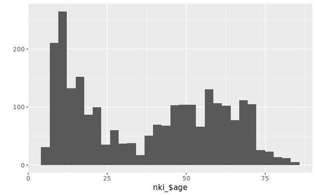

```r
qplot(nki_$age)
```

# Sex

```r
sex_levels <- c("Male", "Female", "Other")
nki_ <- nki_ %>%
  mutate(sex =
           case_when(
             dem_002=="1" ~ "Male",
             dem_002=="2"~ "Female") %>% factor(levels = sex_levels)
         )
```

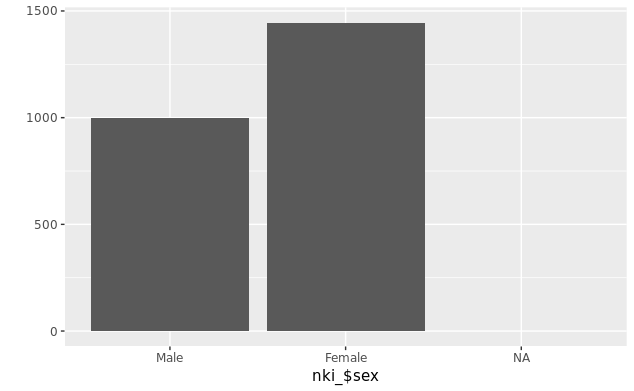

```r
qplot(nki_$sex)
```

# Race

We have the following from BHRC team:

```
#1= American Indian or Native Alaskan
#2= Asian
#3= Black  or African American
#4= Native Hawiian or Other Pacific Islander
#5= White
#6= Other Race
```

```r
nki_ %>%
  select(dem_004) %>%
  table()
```

```
.
   .    1    2    3    4    5    6   DK
   1   24  141  388    7 1819   66    1
```

Only want: black, white, asian, mixed, other, unknown, hispanic

```r
nki_race_old_labels <- c("American Indian or Native Alaskan", "Asian", "Black or African American", "Native Hawiian or Other Pacific Islander", "White", "Other")
nki_race_old_levels <- c(1:6)

race_levels <- c("Black", "White", "Asian", "Mixed", "Hispanic", "Other", "Unknown")

nki_ %>%
  mutate(
    race_old = factor(dem_004, labels = nki_race_old_labels, levels = nki_race_old_levels),
    race = case_when(
    race_old == "American Indian or Native Alaskan"           ~ "Other",
    race_old == "Native Hawiian or Other Pacific Islander"    ~ "Other",
    race_old == "White"                                       ~ "White",
    race_old == "Asian"                                       ~ "Asian",
    race_old == "More than one race"                          ~ "Mixed",
    race_old == "Black or African American"                   ~ "Black",
    race_old == "Unknown or not reported"                     ~ "Unknown"
  ) %>% factor(levels = race_levels)) -> nki_
```

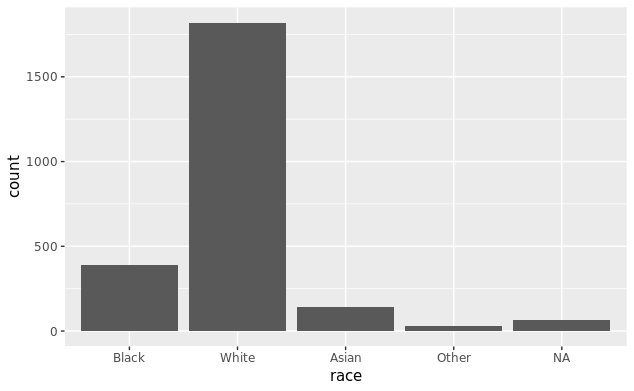

```r
nki_ %>%
  ggplot(aes(x=race)) +
  geom_bar()
```

```
attributes are not identical across measure variables;
they will be droppedIgnoring unknown parameters: check_overlap
```

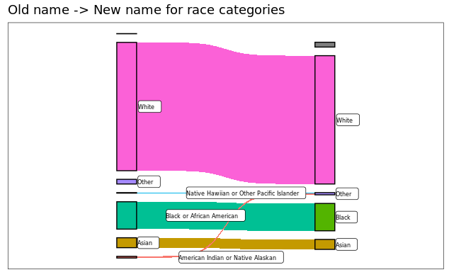

```r
nki_ %>%
  ggsankey::make_long(race_old, race) %>%
  ggplot(aes(x = x,
             next_x = next_x,
             node = node,
             next_node = next_node,
             fill = factor(node),
             label = node)) +
  theme_bw() +
  geom_sankey(node.colour = "black", show.legend = FALSE) +
  geom_sankey_label(size = 2, color = "black", fill= "white", hjust = -0.5, check_overlap=TRUE) +
  theme(legend.position = "none") +
  theme(axis.title = element_blank(),
        axis.text.x = element_blank(),
        axis.text.y = element_blank(),
        panel.grid = element_blank(),
        axis.ticks = element_blank()) +
  labs(title = "Old name -> New name for race categories")
```

# Education

Using reported grade:

> Current grade child participant is in as reported by parent/guardian.

```r
nki_$sesc_10 %>%
  table()
```

```
.
   .    0    1   10   11   12    2    3    4    5    6    7    8    9
2071    8   28   26   17   15   33   38   36   40   41   24   29   33
```

These are numeric grades of education, so no categories necessary.

```r
nki_ <- nki_ %>%
  mutate(
    education = as.numeric(sesc_10) %>%
      scales::ordinal() %>%
      str_c(" Grade")
  ) %>%
  mutate(education = case_when(sesc_10 == "0" ~ "Kindergarten", TRUE ~ education))
```

```
NAs introduced by coercion
```

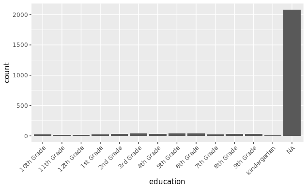

```r
nki_ %>%
  ggplot(aes(x=education)) +
  geom_bar()  +
  theme(axis.text.x = element_text(angle=45, hjust = 1))
```

There are a lot of NAs, so we use the hollingshead education codes to hopefully clear the rest:

Using the Hollingshead education codes:

> Less than seventh grade = 1, Junior high school (including 9h grade) = 2, Partial high school (10th or 11th grade) = 3, High school graduate = 4, Partial college (at least one year or specialized training) = 5, Standard college or university graduation = 6, Graduate/professional = 7, Don’t know = DK, Missing data = MD

```r
nki_$nkises_01a %>%
  table()
```

```
.
  2   3   4   5   6   7
  4  11 139 370 401 351
```

```r
nki_ %>%
  # encode old values
  mutate(hollings_edu = case_when(
    nkises_01a == 1 ~ "Less than seventh grade",
    nkises_01a == 2 ~ "Junior high school (including 9h grade)",
    nkises_01a == 3 ~ "Partial high school (10th or 11th grade)",
    nkises_01a == 4 ~ "High school graduate",
    nkises_01a == 5 ~ "Partial college (at least one year or specialized training)",
    nkises_01a == 6 ~ "Standard college or university graduation",
    nkises_01a == 7 ~ "Graduate/professional",
    nkises_01a == "DK" ~ "Don't know",
    nkises_01a == "MD" ~ "Missing data"
    )
  ) -> nki_

nki_ %>%
  mutate(education = case_when(
    !is.na(education) ~ education,
    str_detect(hollings_edu, "Junior high")          ~ "9th Grade",
    str_detect(hollings_edu, "Partial high")         ~ "11th Grade",
    str_detect(hollings_edu, "High school graduate") ~ "High School Graduate",
    str_detect(hollings_edu, "Partial college")      ~ "Some College",
    str_detect(hollings_edu, "Standard college")     ~ "Bachelor's Degree",
    str_detect(hollings_edu, "professional")         ~ "Graduate Degree",
    ) %>% factor()
  ) -> nki_
```

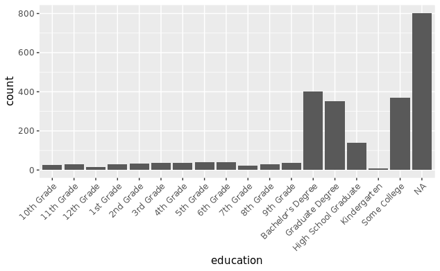

```r
nki_ %>%
  ggplot(aes(x=education)) +
  geom_bar()  +
  theme(axis.text.x = element_text(angle=45, hjust = 1))
```

```
attributes are not identical across measure variables;
they will be droppedIgnoring unknown parameters: check_overlap
```

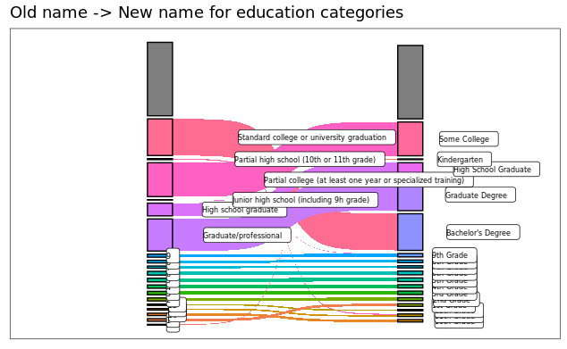

```r
nki_ %>%
  select(hollings_edu, sesc_10, education) %>%
  mutate(source = case_when(
    !is.na(hollings_edu) ~ hollings_edu,
    TRUE ~ sesc_10
    )
  ) %>% replace_with_na(list(source = ".")) %>%# View()
  ggsankey::make_long(source, education) %>%
  ggplot(aes(x = x,
             next_x = next_x,
             node = node,
             next_node = next_node,
             fill = factor(node),
             label = node)) +
  theme_bw() +
  geom_sankey(node.colour = "black", show.legend = FALSE) +
  geom_sankey_label(size = 2, color = "black", fill= "white", hjust = -0.5, check_overlap=TRUE) +
  theme(legend.position = "none") +
  theme(axis.title = element_blank(),
        axis.text.x = element_blank(),
        axis.text.y = element_blank(),
        panel.grid = element_blank(),
        axis.ticks = element_blank()) +
  labs(title = "Old name -> New name for education categories")
```

# Parent Education

Using the same Hollingshead education codes:

> Less than seventh grade = 1, Junior high school (including 9h grade) = 2, Partial high school (10th or 11th grade) = 3, High school graduate = 4, Partial college (at least one year or specialized training) = 5, Standard college or university graduation = 6, Graduate/professional = 7, Don’t know = DK, Missing data = MD

```r
nki_$nkises_05a %>%
  table()
```

```
.
  0   1   2   3   4   5   6   7  DK
 67  47  73  54 448 234 206 145   2
```

```r
nki_ %>%
  mutate(education_m_hollings = case_when(
    nkises_05a == "0" | nkises_05a == "MD" ~ NA_character_,
    nkises_05a == "1" ~ "Less than seventh grade",
    nkises_05a == "2" ~ "Junior high school (including 9h grade)",
    nkises_05a == "3" ~ "Partial high school (10th or 11th grade)",
    nkises_05a == "4" ~ "High school graduate",
    nkises_05a == "5" ~ "Partial college (at least one year or specialized training)",
    nkises_05a == "6" ~ "Standard college or university graduation",
    nkises_05a == "7" ~ "Graduate/professional",
    nkises_05a == "DK" ~ "Don't know",
    ) %>% factor()
  ) -> nki_

nki_ %>%
  mutate(education_m = case_when(
    str_detect(education_m_hollings, "Less than")          ~ "6th Grade",
    str_detect(education_m_hollings, "Junior high")          ~ "9th Grade",
    str_detect(education_m_hollings, "Partial high")         ~ "11th Grade",
    str_detect(education_m_hollings, "High school graduate") ~ "High School Graduate",
    str_detect(education_m_hollings, "Partial college")      ~ "Some College",
    str_detect(education_m_hollings, "Standard college")     ~ "Bachelor's Degree",
    str_detect(education_m_hollings, "professional")         ~ "Graduate Degree",
    str_detect(education_m_hollings, "Don't")         ~ NA_character_
    ) %>% factor()
  ) -> nki_

nki_ %>%
  mutate(education_f_hollings = case_when(
    nkises_07a == "0" | nkises_05a == "MD" ~ NA_character_,
    nkises_07a == "1" ~ "Less than seventh grade",
    nkises_07a == "2" ~ "Junior high school (including 9h grade)",
    nkises_07a == "3" ~ "Partial high school (10th or 11th grade)",
    nkises_07a == "4" ~ "High school graduate",
    nkises_07a == "5" ~ "Partial college (at least one year or specialized training)",
    nkises_07a == "6" ~ "Standard college or university graduation",
    nkises_07a == "7" ~ "Graduate/professional",
    nkises_07a == "DK" ~ "Don't know",
    ) %>% factor()
  ) -> nki_

nki_ %>%
  mutate(education_f = case_when(
    str_detect(education_f_hollings, "Less than")          ~ "6th Grade",
    str_detect(education_f_hollings, "Junior high")          ~ "9th Grade",
    str_detect(education_f_hollings, "Partial high")         ~ "11th Grade",
    str_detect(education_f_hollings, "High school graduate") ~ "High School Graduate",
    str_detect(education_f_hollings, "Partial college")      ~ "Some College",
    str_detect(education_f_hollings, "Standard college")     ~ "Bachelor's Degree",
    str_detect(education_f_hollings, "professional")         ~ "Graduate Degree",
    str_detect(education_f_hollings, "Don't")         ~ NA_character_
    ) %>% factor()
  ) -> nki_
```

```
attributes are not identical across measure variables;
they will be droppedIgnoring unknown parameters: fill
```

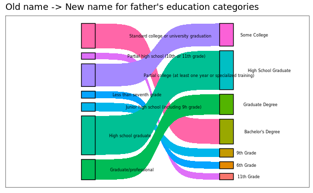

```r
nki_ %>%
  select(education_f_hollings, education_f) %>%
  filter(complete.cases(.)) %>%
  ggsankey::make_long(education_f_hollings, education_f) %>%
  ggplot(aes(x = x,
             next_x = next_x,
             node = node,
             next_node = next_node,
             fill = factor(node),
             label = node)) +
  theme_bw() +
  geom_sankey(node.colour = "black", show.legend = FALSE) +
  geom_sankey_text(size = 2, color = "black", fill= "white", hjust = -0.5, check_overlap=TRUE) +
  theme(legend.position = "none") +
  theme(axis.title = element_blank(),
        axis.text.x = element_blank(),
        axis.text.y = element_blank(),
        panel.grid = element_blank(),
        axis.ticks = element_blank()) +
  labs(title = "Old name -> New name for father's education categories")
```

# Handedness

We get this from the laterality:

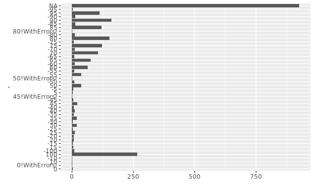

```r
nki_$dehq_16 %>%
  qplot() +
  coord_flip()
```

```r
nki_ %>%
  mutate(
    handedness = case_when(
      str_detect(dehq_16, "Error") == TRUE ~ "NA",
      TRUE                         ~ as.character(dehq_16)
      ),
    handedness = as.numeric(handedness)
    ) %>%
  mutate(
    handedness = case_when(handedness > 0  ~ "Right",
                           handedness < 0  ~ "Left",
                           handedness == 0 ~ "Ambidextrous"
                           ) %>% factor()
  ) -> nki_
```

```
NAs introduced by coercion
```

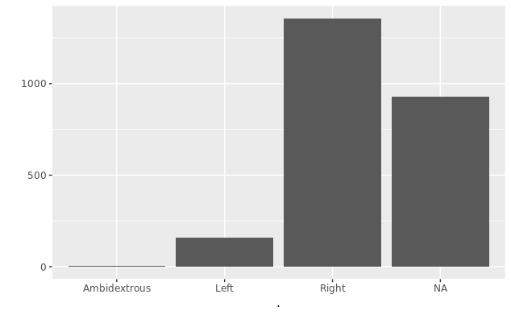

```r
nki_$handedness %>%
  qplot()
```